# Ethereum Wallet Fraud Detection Using Machine Learning

## Objective

Analyze Ethereum wallet transaction behavior and detect suspicious/fraudulent wallets using machine learning techniques.

## Dataset

Ethereum Fraud Detection Dataset (https://www.kaggle.com/datasets/vagifa/ethereum-frauddetection-dataset)

### ERC20 Features

- ERC20 refers to a standard used for Ethereum-based tokens.
- The dataset includes several ERC20-related features that describe token transfer behavior, including transfer amounts, token diversity, and interaction patterns.

```python
import pandas as pd
import numpy as np
import matplotlib.pyplot as plt
import seaborn as sns
import matplotx

pd.set_option("display.max_columns", None)
plt.style.use(matplotx.styles.github["dark"])

from sklearn.preprocessing import LabelEncoder, StandardScaler
from sklearn.model_selection import train_test_split
```

```python
df = pd.read_csv('../data/transaction_dataset.csv')
```

```python
df.columns = (
    df.columns
    .str.strip()
    .str.replace(" ", "_")
)
```

```python
df
```

|  | Unnamed:_0 | Index | Address | FLAG | Avg_min_between_sent_tnx | Avg_min_between_received_tnx | Time_Diff_between_first_and_last_(Mins) | Sent_tnx | Received_Tnx | Number_of_Created_Contracts | Unique_Received_From_Addresses | Unique_Sent_To_Addresses | min_value_received | max_value_received | avg_val_received | min_val_sent | max_val_sent | avg_val_sent | min_value_sent_to_contract | max_val_sent_to_contract | avg_value_sent_to_contract | total_transactions_(including_tnx_to_create_contract | total_Ether_sent | total_ether_received | total_ether_sent_contracts | total_ether_balance | Total_ERC20_tnxs | ERC20_total_Ether_received | ERC20_total_ether_sent | … |
| --- | --- | --- | --- | --- | --- | --- | --- | --- | --- | --- | --- | --- | --- | --- | --- | --- | --- | --- | --- | --- | --- | --- | --- | --- | --- | --- | --- | --- | --- | --- |
| 0 | 0 | 1 | 0x00009277775ac7d0d59eaad8fee3d10ac6c805e8 | 0 | 844.26 | 1093.71 | 704785.63 | 721 | 89 | 0 | 40 | 118 | 0.000000 | 45.806785 | 6.589513 | 0.000000 | 31.220000 | 1.200681 | 0.0 | 0.0 | 0.0 | 810 | 865.691093 | 586.466675 | 0.0 | -279.224419 | 265.0 | 3.558854e+07 | 3.560317e+07 | … |
| 1 | 1 | 2 | 0x0002b44ddb1476db43c868bd494422ee4c136fed | 0 | 12709.07 | 2958.44 | 1218216.73 | 94 | 8 | 0 | 5 | 14 | 0.000000 | 2.613269 | 0.385685 | 0.000000 | 1.800000 | 0.032844 | 0.0 | 0.0 | 0.0 | 102 | 3.087297 | 3.085478 | 0.0 | -0.001819 | 8.0 | 4.034283e+02 | 2.260809e+00 | … |
| 2 | 2 | 3 | 0x0002bda54cb772d040f779e88eb453cac0daa244 | 0 | 246194.54 | 2434.02 | 516729.30 | 2 | 10 | 0 | 10 | 2 | 0.113119 | 1.165453 | 0.358906 | 0.050000 | 3.538616 | 1.794308 | 0.0 | 0.0 | 0.0 | 12 | 3.588616 | 3.589057 | 0.0 | 0.000441 | 8.0 | 5.215121e+02 | 0.000000e+00 | … |
| 3 | 3 | 4 | 0x00038e6ba2fd5c09aedb96697c8d7b8fa6632e5e | 0 | 10219.60 | 15785.09 | 397555.90 | 25 | 9 | 0 | 7 | 13 | 0.000000 | 500.000000 | 99.488840 | 0.000000 | 450.000000 | 70.001834 | 0.0 | 0.0 | 0.0 | 34 | 1750.045862 | 895.399559 | 0.0 | -854.646303 | 14.0 | 1.711105e+04 | 1.141223e+04 | … |
| 4 | 4 | 5 | 0x00062d1dd1afb6fb02540ddad9cdebfe568e0d89 | 0 | 36.61 | 10707.77 | 382472.42 | 4598 | 20 | 1 | 7 | 19 | 0.000000 | 12.802411 | 2.671095 | 0.000000 | 9.000000 | 0.022688 | 0.0 | 0.0 | 0.0 | 4619 | 104.318883 | 53.421897 | 0.0 | -50.896986 | 42.0 | 1.628297e+05 | 1.235399e+05 | … |
| ... | ... | ... | ... | ... | ... | ... | ... | ... | ... | ... | ... | ... | ... | ... | ... | ... | ... | ... | ... | ... | ... | ... | ... | ... | ... | ... | ... | ... | ... | … |
| 9836 | 9836 | 2175 | 0xff481ca14e6c16b79fc8ab299b4d2387ec8ecdd2 | 1 | 12635.10 | 631.39 | 58748.48 | 4 | 13 | 0 | 11 | 4 | 0.004082 | 12.000000 | 2.821060 | 0.465461 | 12.200000 | 9.166365 | 0.0 | 0.0 | 0.0 | 17 | 36.665461 | 36.673777 | 0.0 | 0.008316 | 2.0 | 1.337000e+00 | 0.000000e+00 | … |
| 9837 | 9837 | 2176 | 0xff718805bb9199ebf024ab6acd333e603ad77c85 | 1 | 0.00 | 0.00 | 0.00 | 0 | 0 | 0 | 0 | 0 | 0.000000 | 0.000000 | 0.000000 | 0.000000 | 0.000000 | 0.000000 | 0.0 | 0.0 | 0.0 | 0 | 0.000000 | 0.000000 | 0.0 | 0.000000 | 1.0 | 1.337000e+01 | 0.000000e+00 | … |
| 9838 | 9838 | 2177 | 0xff8e6af02d41a576a0c82f7835535193e1a6bccc | 1 | 2499.44 | 2189.29 | 261601.88 | 67 | 43 | 0 | 31 | 44 | 0.001078 | 21.310000 | 1.234192 | 0.004000 | 9.500000 | 0.922179 | 0.0 | 0.0 | 0.0 | 110 | 61.785995 | 53.070252 | 0.0 | -8.715743 | 5.0 | 1.503470e+03 | 0.000000e+00 | … |
| 9839 | 9839 | 2178 | 0xffde23396d57e10abf58bd929bb1e856c7718218 | 1 | 0.00 | 0.00 | 0.00 | 0 | 1 | 0 | 1 | 0 | 0.500000 | 0.500000 | 0.500000 | 0.000000 | 0.000000 | 0.000000 | 0.0 | 0.0 | 0.0 | 1 | 0.000000 | 0.500000 | 0.0 | 0.500000 | NaN | NaN | NaN | … |
| 9840 | 9840 | 2179 | 0xd624d046edbdef805c5e4140dce5fb5ec1b39a3c | 1 | 37242.70 | 149.56 | 670817.33 | 18 | 3 | 0 | 1 | 5 | 0.795233 | 18998.000000 | 6333.265078 | 0.900000 | 1000.000000 | 644.427778 | 0.0 | 0.0 | 0.0 | 21 | 11599.700000 | 18999.795230 | 0.0 | 7400.095233 | 44.0 | 6.007075e+04 | 0.000000e+00 | … |

9841 rows × 51 columns

```python
df = df.drop(columns=["Unnamed:_0", "Index", "Address"])
```

```python
df.describe().T
```

|  | count | mean | std | min | 25% | 50% | 75% | max |
| --- | --- | --- | --- | --- | --- | --- | --- | --- |
| FLAG | 9841.0 | 2.214206e-01 | 4.152241e-01 | 0.00 | 0.000000 | 0.000000e+00 | 0.000000 | 1.000000e+00 |
| Avg_min_between_sent_tnx | 9841.0 | 5.086879e+03 | 2.148655e+04 | 0.00 | 0.000000 | 1.734000e+01 | 565.470000 | 4.302877e+05 |
| Avg_min_between_received_tnx | 9841.0 | 8.004851e+03 | 2.308171e+04 | 0.00 | 0.000000 | 5.097700e+02 | 5480.390000 | 4.821755e+05 |
| Time_Diff_between_first_and_last_(Mins) | 9841.0 | 2.183333e+05 | 3.229379e+05 | 0.00 | 316.930000 | 4.663703e+04 | 304070.980000 | 1.954861e+06 |
| Sent_tnx | 9841.0 | 1.159317e+02 | 7.572264e+02 | 0.00 | 1.000000 | 3.000000e+00 | 11.000000 | 1.000000e+04 |
| Received_Tnx | 9841.0 | 1.637009e+02 | 9.408366e+02 | 0.00 | 1.000000 | 4.000000e+00 | 27.000000 | 1.000000e+04 |
| Number_of_Created_Contracts | 9841.0 | 3.729702e+00 | 1.414456e+02 | 0.00 | 0.000000 | 0.000000e+00 | 0.000000 | 9.995000e+03 |
| Unique_Received_From_Addresses | 9841.0 | 3.036094e+01 | 2.986211e+02 | 0.00 | 1.000000 | 2.000000e+00 | 5.000000 | 9.999000e+03 |
| Unique_Sent_To_Addresses | 9841.0 | 2.584016e+01 | 2.638204e+02 | 0.00 | 1.000000 | 2.000000e+00 | 3.000000 | 9.287000e+03 |
| min_value_received | 9841.0 | 4.384515e+01 | 3.259291e+02 | 0.00 | 0.001000 | 9.585600e-02 | 2.000000 | 1.000000e+04 |
| max_value_received | 9841.0 | 5.231525e+02 | 1.300882e+04 | 0.00 | 1.000000 | 6.000000e+00 | 67.067040 | 8.000000e+05 |
| avg_val_received | 9841.0 | 1.007117e+02 | 2.885002e+03 | 0.00 | 0.426905 | 1.729730e+00 | 22.000000 | 2.836188e+05 |
| min_val_sent | 9841.0 | 4.800090e+00 | 1.386097e+02 | 0.00 | 0.000000 | 4.912600e-02 | 0.998800 | 1.200000e+04 |
| max_val_sent | 9841.0 | 3.146173e+02 | 6.629213e+03 | 0.00 | 0.164577 | 4.999380e+00 | 61.520653 | 5.200000e+05 |
| avg_val_sent | 9841.0 | 4.475573e+01 | 2.390802e+02 | 0.00 | 0.086184 | 1.606000e+00 | 21.999380 | 1.200000e+04 |
| min_value_sent_to_contract | 9841.0 | 3.048471e-06 | 2.253968e-04 | 0.00 | 0.000000 | 0.000000e+00 | 0.000000 | 2.000000e-02 |
| max_val_sent_to_contract | 9841.0 | 7.725739e-06 | 5.158151e-04 | 0.00 | 0.000000 | 0.000000e+00 | 0.000000 | 4.602900e-02 |
| avg_value_sent_to_contract | 9841.0 | 5.387054e-06 | 3.234341e-04 | 0.00 | 0.000000 | 0.000000e+00 | 0.000000 | 2.301400e-02 |
| total_transactions_(including_tnx_to_create_contract | 9841.0 | 2.833624e+02 | 1.352404e+03 | 0.00 | 4.000000 | 8.000000e+00 | 54.000000 | 1.999500e+04 |
| total_Ether_sent | 9841.0 | 1.016092e+04 | 3.583227e+05 | 0.00 | 0.226206 | 1.248680e+01 | 100.998974 | 2.858096e+07 |
| total_ether_received | 9841.0 | 1.163832e+04 | 3.642048e+05 | 0.00 | 2.670424 | 3.052963e+01 | 101.000000 | 2.858159e+07 |
| total_ether_sent_contracts | 9841.0 | 7.725710e-06 | 5.158125e-04 | 0.00 | 0.000000 | 0.000000e+00 | 0.000000 | 4.602871e-02 |
| total_ether_balance | 9841.0 | 1.477395e+03 | 2.424254e+05 | -15605352.04 | 0.000621 | 1.722000e-03 | 0.044520 | 1.428864e+07 |
| Total_ERC20_tnxs | 9012.0 | 3.625566e+01 | 4.475289e+02 | 0.00 | 0.000000 | 1.000000e+00 | 3.000000 | 1.000100e+04 |
| ERC20_total_Ether_received | 9012.0 | 1.296207e+08 | 1.053858e+10 | 0.00 | 0.000000 | 1.000000e-12 | 100.337000 | 1.000020e+12 |
| ERC20_total_ether_sent | 9012.0 | 1.386849e+07 | 1.180390e+09 | 0.00 | 0.000000 | 0.000000e+00 | 0.000000 | 1.120000e+11 |
| ERC20_total_Ether_sent_contract | 9012.0 | 1.109392e+02 | 6.128635e+03 | 0.00 | 0.000000 | 0.000000e+00 | 0.000000 | 4.160000e+05 |
| ERC20_uniq_sent_addr | 9012.0 | 5.638038e+00 | 1.052525e+02 | 0.00 | 0.000000 | 0.000000e+00 | 0.000000 | 6.582000e+03 |
| ERC20_uniq_rec_addr | 9012.0 | 7.598535e+00 | 8.181847e+01 | 0.00 | 0.000000 | 1.000000e+00 | 2.000000 | 4.293000e+03 |
| ERC20_uniq_sent_addr.1 | 9012.0 | 3.439858e-03 | 6.569787e-02 | 0.00 | 0.000000 | 0.000000e+00 | 0.000000 | 3.000000e+00 |
| ERC20_uniq_rec_contract_addr | 9012.0 | 4.901909e+00 | 1.724658e+01 | 0.00 | 0.000000 | 1.000000e+00 | 2.000000 | 7.820000e+02 |
| ERC20_avg_time_between_sent_tnx | 9012.0 | 0.000000e+00 | 0.000000e+00 | 0.00 | 0.000000 | 0.000000e+00 | 0.000000 | 0.000000e+00 |
| ERC20_avg_time_between_rec_tnx | 9012.0 | 0.000000e+00 | 0.000000e+00 | 0.00 | 0.000000 | 0.000000e+00 | 0.000000 | 0.000000e+00 |
| ERC20_avg_time_between_rec_2_tnx | 9012.0 | 0.000000e+00 | 0.000000e+00 | 0.00 | 0.000000 | 0.000000e+00 | 0.000000 | 0.000000e+00 |
| ERC20_avg_time_between_contract_tnx | 9012.0 | 0.000000e+00 | 0.000000e+00 | 0.00 | 0.000000 | 0.000000e+00 | 0.000000 | 0.000000e+00 |
| ERC20_min_val_rec | 9012.0 | 4.856147e+02 | 1.688328e+04 | 0.00 | 0.000000 | 0.000000e+00 | 0.001523 | 9.900000e+05 |
| ERC20_max_val_rec | 9012.0 | 1.252524e+08 | 1.053741e+10 | 0.00 | 0.000000 | 0.000000e+00 | 99.000000 | 1.000000e+12 |
| ERC20_avg_val_rec | 9012.0 | 4.346203e+06 | 2.141192e+08 | 0.00 | 0.000000 | 0.000000e+00 | 29.464673 | 1.724181e+10 |
| ERC20_min_val_sent | 9012.0 | 1.174126e+04 | 1.053567e+06 | 0.00 | 0.000000 | 0.000000e+00 | 0.000000 | 1.000000e+08 |
| ERC20_max_val_sent | 9012.0 | 1.303594e+07 | 1.179905e+09 | 0.00 | 0.000000 | 0.000000e+00 | 0.000000 | 1.120000e+11 |
| ERC20_avg_val_sent | 9012.0 | 6.318389e+06 | 5.914764e+08 | 0.00 | 0.000000 | 0.000000e+00 | 0.000000 | 5.614756e+10 |
| ERC20_min_val_sent_contract | 9012.0 | 0.000000e+00 | 0.000000e+00 | 0.00 | 0.000000 | 0.000000e+00 | 0.000000 | 0.000000e+00 |
| ERC20_max_val_sent_contract | 9012.0 | 0.000000e+00 | 0.000000e+00 | 0.00 | 0.000000 | 0.000000e+00 | 0.000000 | 0.000000e+00 |
| ERC20_avg_val_sent_contract | 9012.0 | 0.000000e+00 | 0.000000e+00 | 0.00 | 0.000000 | 0.000000e+00 | 0.000000 | 0.000000e+00 |
| ERC20_uniq_sent_token_name | 9012.0 | 1.384931e+00 | 6.735121e+00 | 0.00 | 0.000000 | 0.000000e+00 | 0.000000 | 2.130000e+02 |
| ERC20_uniq_rec_token_name | 9012.0 | 4.826676e+00 | 1.667861e+01 | 0.00 | 0.000000 | 1.000000e+00 | 2.000000 | 7.370000e+02 |

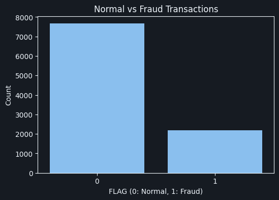

```
FLAG
0    77.857941
1    22.142059
Name: proportion, dtype: float64
```

```python
df["FLAG"].value_counts()

plt.figure(figsize=(6, 4))
sns.countplot(x="FLAG", data=df)
plt.title("Normal vs Fraud Transactions")
plt.xlabel("FLAG (0: Normal, 1: Fraud)")
plt.ylabel("Count")
plt.show()

fraud_percentage = df["FLAG"].value_counts(normalize=True) * 100
print(fraud_percentage)
```

### Observation

The dataset is imbalanced, with significantly fewer fraud wallets compared to legitimate wallets.

```python
correlation = df.corr(numeric_only=True)["FLAG"].sort_values(ascending=False)

print(correlation)
```

```
FLAG                                                    1.000000
ERC20_min_val_sent                                      0.025364
ERC20_avg_val_sent                                      0.025044
ERC20_max_val_sent                                      0.025038
ERC20_total_ether_sent                                  0.024762
ERC20_total_Ether_sent_contract                         0.013514
ERC20_min_val_rec                                       0.011163
ERC20_uniq_sent_token_name                              0.009249
ERC20_avg_val_rec                                       0.007881
min_val_sent                                            0.006626
ERC20_uniq_sent_addr.1                                 -0.003047
total_ether_balance                                    -0.003229
ERC20_max_val_rec                                      -0.004313
ERC20_total_Ether_received                             -0.004475
min_value_sent_to_contract                             -0.007213
max_val_sent_to_contract                               -0.007988
total_ether_sent_contracts                             -0.007988
avg_value_sent_to_contract                             -0.008883
avg_val_received                                       -0.011881
Number_of_Created_Contracts                            -0.013711
total_Ether_sent                                       -0.014993
total_ether_received                                   -0.016900
ERC20_uniq_rec_addr                                    -0.017539
ERC20_uniq_rec_token_name                              -0.018047
ERC20_uniq_rec_contract_addr                           -0.018527
max_value_received                                     -0.019259
ERC20_uniq_sent_addr                                   -0.020554
min_value_received                                     -0.021641
max_val_sent                                           -0.022437
Total_ERC20_tnxs                                       -0.025697
Avg_min_between_sent_tnx                               -0.029754
Unique_Received_From_Addresses                         -0.031941
Unique_Sent_To_Addresses                               -0.045584
avg_val_sent                                           -0.063556
Sent_tnx                                               -0.078006
Received_Tnx                                           -0.079316
total_transactions_(including_tnx_to_create_contract   -0.100289
Avg_min_between_received_tnx                           -0.118533
Time_Diff_between_first_and_last_(Mins)                -0.269354
ERC20_avg_time_between_sent_tnx                              NaN
ERC20_avg_time_between_rec_tnx                               NaN
ERC20_avg_time_between_rec_2_tnx                             NaN
ERC20_avg_time_between_contract_tnx                          NaN
ERC20_min_val_sent_contract                                  NaN
ERC20_max_val_sent_contract                                  NaN
ERC20_avg_val_sent_contract                                  NaN
Name: FLAG, dtype: float64
```

## Finding Features with the Highest Correlation to the Fraud Label `FLAG`:

```python
best_features = correlation[1:11]
```

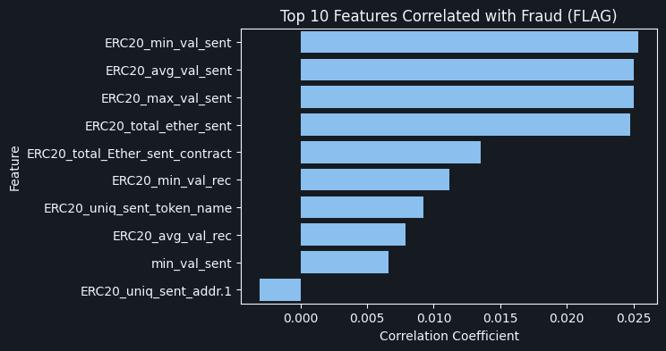

```python
plt.figure(figsize=(6, 4))
plt.title("Top 10 Features Correlated with Fraud (FLAG)")
plt.xlabel("Correlation Coefficient")
plt.ylabel("Feature")
sns.barplot(x = best_features.values,
            y=best_features.index
)
```

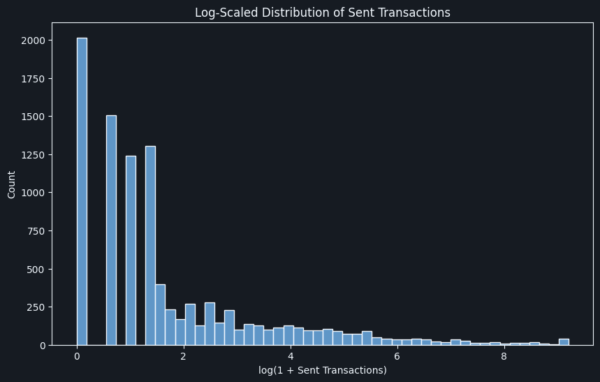

```python
plt.figure(figsize=(10,6))

sns.histplot(
    np.log1p(df["Sent_tnx"]),
    bins=50
)

plt.title("Log-Scaled Distribution of Sent Transactions")
plt.xlabel("log(1 + Sent Transactions)")
plt.ylabel("Count")

plt.show()
```

#### Observations:

- Most wallets exhibit relatively low transaction activity
- A small number of wallets are extremely active
- The dataset contains significant outliers
- Wallet activity is not normally distributed

## Behaviourial Analysis of Normal and Fraud Wallets:

Now, we investigate the behaviourial distributions between the normal and fraud wallets

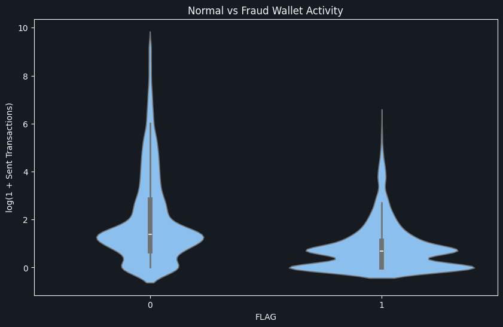

```python
plt.figure(figsize=(10,6))

sns.violinplot(
    x=df["FLAG"],
    y=np.log1p(df["Sent_tnx"])
)

plt.title("Normal vs Fraud Wallet Activity")
plt.xlabel("FLAG")
plt.ylabel("log(1 + Sent Transactions)")

plt.show()
```

### Observation

- Normal wallets generally exhibit higher transaction activity compared to fraud wallets.
- The fraud wallets are more concentrated around lower transaction counts, while normal wallets show a wider range of activity.

- ERC20 min val sent
- ERC20 avg val sent
- ERC20 max val sent
- ERC20 total ether sent

```python
important_features = [
    "ERC20 min_val_sent",
    "ERC20 avg_val_sent",
    "ERC20 max_val_sent",
    "ERC20 total_ether_sent"
]
```

Now, we create a function that visualizes the behaviour of the Fraud Label `FLAG` for a feature

```python
def compare_feature(feature_name):

    plt.figure(figsize=(10,6))

    sns.violinplot(
        x=df["FLAG"],
        y=np.log1p(df[feature_name])
    )

    plt.title(f"Normal vs Fraud Wallet: {feature_name}")

    plt.xlabel("FLAG")
    plt.ylabel(f"log(1 + {feature_name})")

    plt.show()
```

### 1. ERC20_min_val_sent:

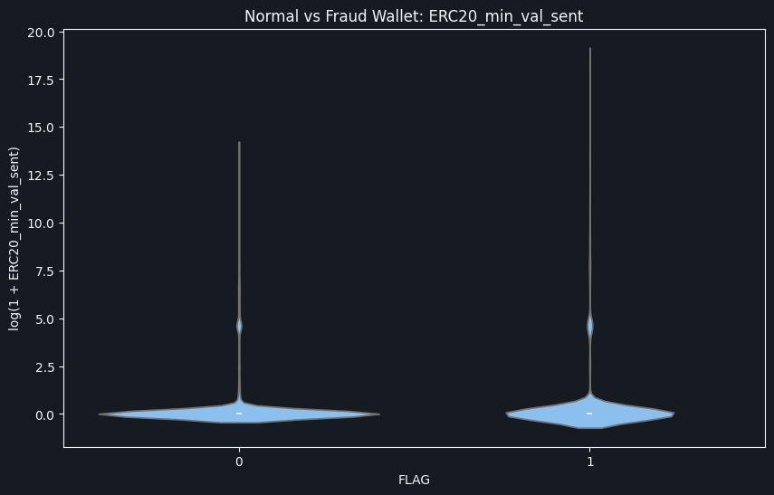

```python
compare_feature("ERC20_min_val_sent")
```

### 2. ERC20_avg_val_sent:

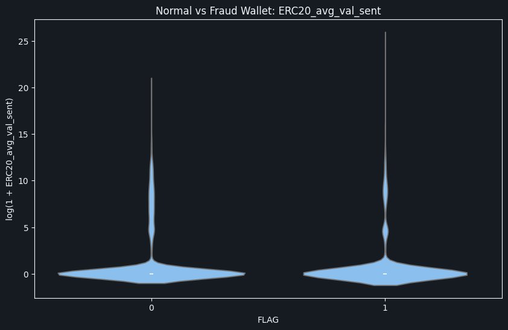

```python
compare_feature("ERC20_avg_val_sent")
```

### 3. ERC20_max_val_sent:

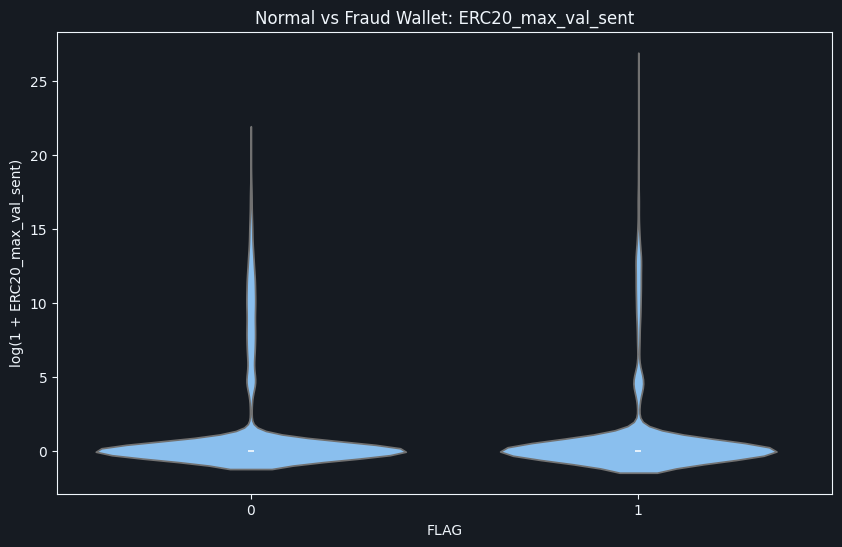

```python
compare_feature("ERC20_max_val_sent")
```

### 4. ERC20_total_ether_sent:

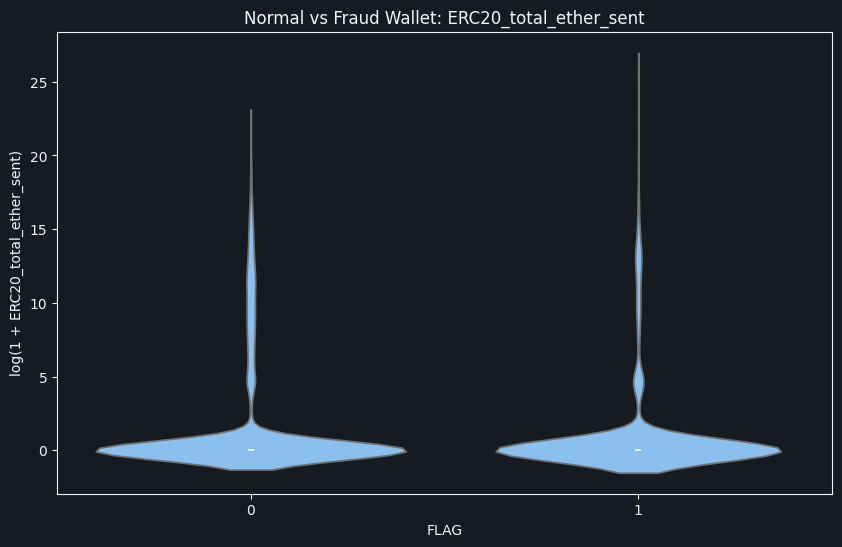

```python
compare_feature("ERC20_total_ether_sent")
```

#### Normal Wallets (FLAG = 0) show:

- broader distributions
- greater variability
- more diverse transfer behavior

while:

### Observation — ERC20 Transfer Behaviour

The ERC20-related transfer features exhibit noticeable behavioral differences between fraudulent and legitimate wallets.

## Data Preprocessing:

```python
print(df.shape)
```

```
(9841, 48)
```

#### Checking & Handling Missing Values:

```python
missing_values = df.isnull().sum()

missing_values[missing_values > 0].sort_values(ascending=False)
```

```
ERC20_most_sent_token_type             2697
ERC20_most_rec_token_type               871
ERC20_total_ether_sent                  829
ERC20_total_Ether_received              829
ERC20_uniq_sent_addr                    829
ERC20_uniq_rec_addr                     829
ERC20_uniq_sent_addr.1                  829
ERC20_total_Ether_sent_contract         829
Total_ERC20_tnxs                        829
ERC20_avg_time_between_sent_tnx         829
ERC20_uniq_rec_contract_addr            829
ERC20_avg_time_between_rec_tnx          829
ERC20_avg_time_between_rec_2_tnx        829
ERC20_max_val_rec                       829
ERC20_avg_val_rec                       829
ERC20_avg_time_between_contract_tnx     829
ERC20_min_val_rec                       829
ERC20_max_val_sent                      829
ERC20_min_val_sent                      829
ERC20_avg_val_sent                      829
ERC20_min_val_sent_contract             829
ERC20_avg_val_sent_contract             829
ERC20_max_val_sent_contract             829
ERC20_uniq_rec_token_name               829
ERC20_uniq_sent_token_name              829
dtype: int64
```

We will use median value of each feature to replace the missing numerical values.

```python
cols = df.select_dtypes(include = np.number).columns

for col in cols:
    df[col] = df[col].fillna(df[col].median())
```

#### Converting Categorical Features into Numbers using Label Encoding:

```python
categorical_cols = df.select_dtypes(include = "object").columns

categorical_cols
```

```
Index(['ERC20_most_sent_token_type', 'ERC20_most_rec_token_type'], dtype='str')
```

```python
label_encoders = {}

for col in categorical_cols:
    le = LabelEncoder()
    df[col] = le.fit_transform(df[col].astype(str))
    label_encoders[col] = le
```

```python
df.info()
```

```
<class 'pandas.DataFrame'>
RangeIndex: 9841 entries, 0 to 9840
Data columns (total 48 columns):
 #   Column                                                Non-Null Count  Dtype
---  ------                                                --------------  -----
 0   FLAG                                                  9841 non-null   int64
 1   Avg_min_between_sent_tnx                              9841 non-null   float64
 2   Avg_min_between_received_tnx                          9841 non-null   float64
 3   Time_Diff_between_first_and_last_(Mins)               9841 non-null   float64
 4   Sent_tnx                                              9841 non-null   int64
 5   Received_Tnx                                          9841 non-null   int64
 6   Number_of_Created_Contracts                           9841 non-null   int64
 7   Unique_Received_From_Addresses                        9841 non-null   int64
 8   Unique_Sent_To_Addresses                              9841 non-null   int64
 9   min_value_received                                    9841 non-null   float64
```

[output cut: 40 more lines]

#### Separating Data into Features and Labels:

- X - input features
- y - target labels

```python
X = df.drop(columns=["FLAG"])

y = df["FLAG"]
```

#### Feature Scaling:

Used because:

- Transaction values vary enormously
- Data contains extreme outliers
- Some features use vastly different scales

```python
sc = StandardScaler()

X_scaled = sc.fit_transform(X)
```

#### Train-Test Split: (80-20)

```python
X_train, X_test, y_train, y_test = train_test_split(
    X_scaled, y, test_size=0.2, random_state=18, stratify=y
)
```

```python
print("Training Features Shape:", X_train.shape)
print("Testing Features Shape:", X_test.shape)

print("Training Labels Shape:", y_train.shape)
print("Testing Labels Shape:", y_test.shape)
```

```
Training Features Shape: (7872, 47)
Testing Features Shape: (1969, 47)
Training Labels Shape: (7872,)
Testing Labels Shape: (1969,)
```

## Baseline Machine Learning Models

#### Objective

After preprocessing the dataset, the next step is to train baseline machine learning models for Ethereum wallet fraud detection.

We will do the following tasks:

- establish baseline fraud classification performance using Logistic Regression model
- evaluate model effectiveness for Logistic Regression, Random Forest and XGBoost
- analyze fraud detection capability for each model
- compare model behaviour

The first model selected is Logistic Regression because it is simple, interpretable, and widely used for binary classification problems.

```python
from sklearn.linear_model import LogisticRegression

from sklearn.metrics import (
    accuracy_score,
    precision_score,
    recall_score,
    f1_score,
    classification_report,
    confusion_matrix,
    ConfusionMatrixDisplay,
    roc_auc_score
)
```

## 1. Logistic Regression:

```python
lr = LogisticRegression(random_state=18,
                        max_iter=1000)
```

```python
lr.fit(X_train, y_train)
```

```
LogisticRegression(max_iter=1000, random_state=18)
```

```python
lr_preds = lr.predict(X_test)
```

#### Accuracy, Precision, Recall & F1 Score for Logistic Regression:

Particular attention is given to Recall, since failing to detect fraud wallets is costly in real-world fraud detection systems.

```python
lr_accuracy = accuracy_score(y_test, lr_preds)
lr_precision = precision_score(y_test, lr_preds)
lr_recall = recall_score(y_test, lr_preds)
lr_f1score = f1_score(y_test, lr_preds)
```

```python
print("Logistic Regression Performance:")

print(f"Accuracy: {lr_accuracy}")
print(f"Precision: {lr_precision}")
print(f"Recall: {lr_recall}")
print(f"F1-Score: {lr_f1score}")
```

```
Logistic Regression Performance:
Accuracy: 0.9334687658710005
Precision: 0.8657074340527577
Recall: 0.8279816513761468
F1-Score: 0.8464243845252052
```

#### Classification Report for Logistic Regression:

```python
print(classification_report(y_test, lr_preds))
```

```
              precision    recall  f1-score   support

           0       0.95      0.96      0.96      1533
           1       0.87      0.83      0.85       436

    accuracy                           0.93      1969
   macro avg       0.91      0.90      0.90      1969
weighted avg       0.93      0.93      0.93      1969
```

#### Confusion Matrix for Logistic Regression:

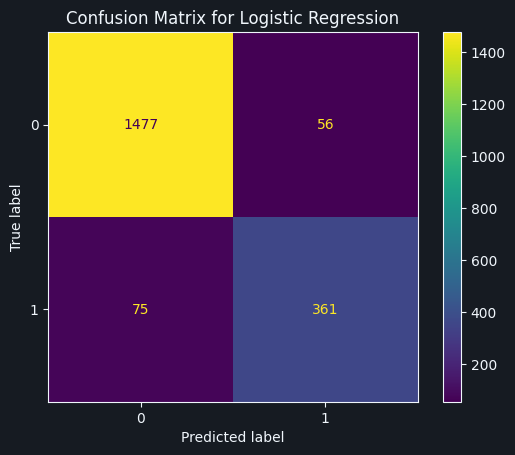

```python
conf_mtrx_lr = confusion_matrix(y_test, lr_preds)

disp = ConfusionMatrixDisplay(confusion_matrix=conf_mtrx_lr, display_labels=lr.classes_)
disp.plot()

plt.title("Confusion Matrix for Logistic Regression")
plt.show()
```

#### ROC-AUC Score for Logistic Regression:

```python
lr_probs = lr.predict_proba(X_test)[:, 1]
```

```python
lr_roc_auc = roc_auc_score(y_test, lr_probs)

print(f"ROC-AUC Score for Logistic Regression: {lr_roc_auc}")
```

```
ROC-AUC Score for Logistic Regression: 0.9405973775711114
```

## 2. Random Forest:

```python
from sklearn.ensemble import RandomForestClassifier
```

```python
rf = RandomForestClassifier(random_state=18,
                            n_estimators=100,
                            class_weight="balanced")
```

```python
rf.fit(X_train, y_train)
```

```
RandomForestClassifier(class_weight='balanced', random_state=18)
```

```python
rf_preds = rf.predict(X_test)
```

#### Accuracy, Precision, Recall & F1-Score for Random Forest:

Particular attention is given to Recall, since failing to detect fraud wallets is costly in real-world fraud detection systems.

```python
rf_accuracy = accuracy_score(y_test, rf_preds)
rf_precision = precision_score(y_test, rf_preds)
rf_recall = recall_score(y_test, rf_preds)
rf_f1score = f1_score(y_test, rf_preds)
```

```python
print("Random Forest Performance:")

print(f"Accuracy: {rf_accuracy}")
print(f"Precision: {rf_precision}")
print(f"Recall: {rf_recall}")
print(f"F1-Score: {rf_f1score}")
```

```
Random Forest Performance:
Accuracy: 0.9903504316912138
Precision: 1.0
Recall: 0.9564220183486238
F1-Score: 0.977725674091442
```

#### Classification Report for Random Forest:

```python
print(classification_report(y_test, rf_preds))
```

```
              precision    recall  f1-score   support

           0       0.99      1.00      0.99      1533
           1       1.00      0.96      0.98       436

    accuracy                           0.99      1969
   macro avg       0.99      0.98      0.99      1969
weighted avg       0.99      0.99      0.99      1969
```

#### Confusion Matrix for Random Forest:

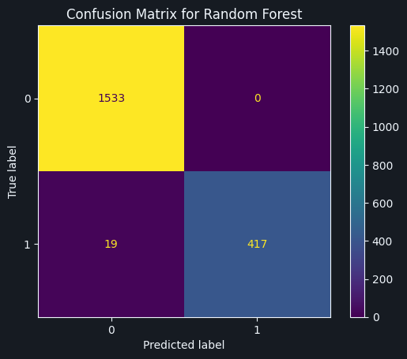

```python
rf_conf_matrix = confusion_matrix(y_test, rf_preds)

disp_rf = ConfusionMatrixDisplay(confusion_matrix=rf_conf_matrix, display_labels=rf.classes_)
disp_rf.plot()

plt.title("Confusion Matrix for Random Forest")
plt.show()
```

### ROC-AUC Score for Random Forest:

```python
rf_probs = rf.predict_proba(X_test)[:,1]
```

```python
rf_roc_auc = roc_auc_score(y_test, rf_probs)

print(f"ROC-AUC Score for Random Forest: {rf_roc_auc}")
```

```
ROC-AUC Score for Random Forest: 0.9992182684309114
```

## XGBoost Classification

XGBoost improves prediction performance by sequentially correcting errors made by previous decision trees, allowing it to capture highly complex behavioral relationships in blockchain transaction data.

```python
from xgboost import XGBClassifier
```

#### XGBoost Initialization

```python
xgb = XGBClassifier(objective = 'binary:logistic',
                    eval_metric='logloss',
                    random_state=18,
)
```

```python
xgb.fit(X_train, y_train)
```

```
XGBClassifier(base_score=None, booster=None, callbacks=None,
              colsample_bylevel=None, colsample_bynode=None,
              colsample_bytree=None, device=None, early_stopping_rounds=None,
              enable_categorical=False, eval_metric='logloss',
              feature_types=None, feature_weights=None, gamma=None,
              grow_policy=None, importance_type=None,
              interaction_constraints=None, learning_rate=None, max_bin=None,
              max_cat_threshold=None, max_cat_to_onehot=None,
              max_delta_step=None, max_depth=None, max_leaves=None,
              min_child_weight=None, missing=nan, monotone_constraints=None,
              multi_strategy=None, n_estimators=None, n_jobs=None,
              num_parallel_tree=None, ...)
```

```python
xgb_preds = xgb.predict(X_test)
```

#### Accuracy, Precision, Recall & F1-Score for XGBoost:

Particular attention is given to Recall, since failing to detect fraud wallets is costly in real-world fraud detection systems.

```python
xgb_accuracy = accuracy_score(y_test, xgb_preds)
xgb_precision = precision_score(y_test, xgb_preds)
xgb_recall = recall_score(y_test, xgb_preds)
xgb_f1score = f1_score(y_test, xgb_preds)
```

```python
print("XGBoost Performance:")

print(f"Accuracy: {xgb_accuracy}")
print(f"Precision: {xgb_precision}")
print(f"Recall: {xgb_recall}")
print(f"F1-Score: {xgb_f1score}")
```

```
XGBoost Performance:
Accuracy: 0.9964448958862366
Precision: 1.0
Recall: 0.9839449541284404
F1-Score: 0.991907514450867
```

#### Classification Report for XGBoost:

```python
print(classification_report(y_test, xgb_preds))
```

```
              precision    recall  f1-score   support

           0       1.00      1.00      1.00      1533
           1       1.00      0.98      0.99       436

    accuracy                           1.00      1969
   macro avg       1.00      0.99      0.99      1969
weighted avg       1.00      1.00      1.00      1969
```

#### Confusion Matrix for XGBoost:

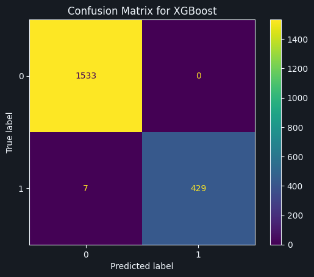

```python
xgb_conf_matrix = confusion_matrix(y_test, xgb_preds)

xgb_disp = ConfusionMatrixDisplay(confusion_matrix=xgb_conf_matrix, display_labels=xgb.classes_)
xgb_disp.plot()

plt.title("Confusion Matrix for XGBoost")
plt.show()
```

#### ROC-AUC Score for XGBoost:

```python
xgb_roc_auc = roc_auc_score(y_test, xgb.predict_proba(X_test)[:,1])

print(f"ROC-AUC Score for XGBoost: {xgb_roc_auc}")
```

```
ROC-AUC Score for XGBoost: 0.9986145771617683
```

#### Feature Importance Scores (XGBoost):

```python
xgb_feature_imp = pd.DataFrame({
    "Feature": X.columns,
    "Importance": xgb.feature_importances_
}).sort_values(by="Importance", ascending=False)
```

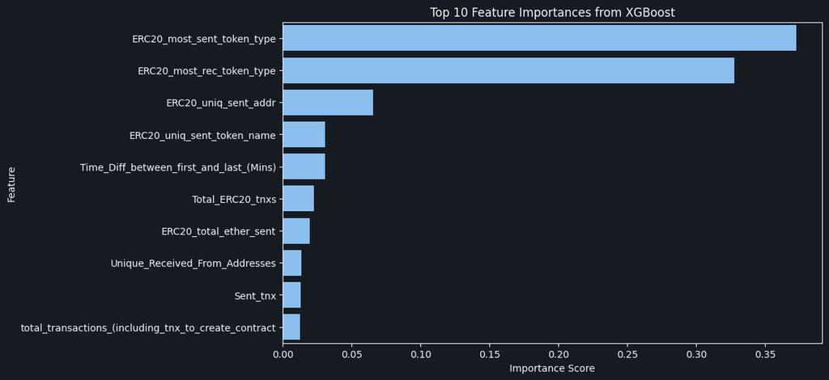

```python
plt.figure(figsize=(10,6))

sns.barplot(
    data = xgb_feature_imp.head(10),
    x = "Importance",
    y = "Feature"
)

plt.title("Top 10 Feature Importances from XGBoost")

plt.xlabel("Importance Score")
plt.ylabel("Feature")

plt.show()
```

#### XGBoost Feature Importance Analysis:

Features:

- `ERC20_most_sent_token_type`
- `ERC20_most_rec_token_type`

were significantly more important than other features.

This suggests that certain token ecosystems may be closely associated with phishing activity, scam wallets, or suspicious transfer patterns.

Unlike the earlier correlation analysis, XGBoost captured deeper non-linear relationships and feature interactions between wallet behavior and token activity.

This indicates that Ethereum fraud detection depends not only on how much a wallet transacts, but also on the types of tokens and interaction patterns involved.

```python
comparison_df = pd.DataFrame({
    "Model": [
        "Logistic Regression",
        "Random Forest",
        "XGBoost"
    ],

    "Accuracy": [
        lr_accuracy,
        rf_accuracy,
        xgb_accuracy
    ],

    "Precision": [
        lr_precision,
        rf_precision,
        xgb_precision
    ],

    "Recall": [
        lr_recall,
        rf_recall,
        xgb_recall
    ],

    "F1 Score": [
        lr_f1score,
        rf_f1score,
        xgb_f1score
    ],

    "ROC-AUC": [
        lr_roc_auc,
        rf_roc_auc,
        xgb_roc_auc
    ]
})

comparison_df
```

|  | Model | Accuracy | Precision | Recall | F1 Score | ROC-AUC |
| --- | --- | --- | --- | --- | --- | --- |
| 0 | Logistic Regression | 0.933469 | 0.865707 | 0.827982 | 0.846424 | 0.940597 |
| 1 | Random Forest | 0.990350 | 1.000000 | 0.956422 | 0.977726 | 0.999218 |
| 2 | XGBoost | 0.996445 | 1.000000 | 0.983945 | 0.991908 | 0.998615 |

# Final Conclusion

This project explored Ethereum wallet fraud detection using machine learning.

The workflow included:

- exploratory data analysis (EDA)
- behavioral visualization
- data preprocessing
- Logistic Regression
- Random Forest
- XGBoost
- feature importance analysis

The results showed that ERC20 transaction behavior and token interaction patterns contain highly predictive fraud-related signals.

Among the evaluated models:

- Logistic Regression established a strong base model
- Random Forest significantly improved fraud detection rates
- XGBoost achieved the best overall performance with near perfect recall (~98.39%)

The project also demonstrated that non-linear models are highly effective for blockchain fraud detection tasks involving complex wallet behavior patterns.